# Plotting tools

**visOmopResults** offer some plotting tools that can be very useful. These tools are useful to plot either `<summarised_result>` dataset or a usual `<data.frame>`.

```r
  library(visOmopResults)
```

## Plotting with a `<summarised_result>`

For the purpose of this vignette we will turn summarise the dataset penguins from the palmerpenguins package using `PatientProfiles::summariseResult()`

```r
library(PatientProfiles)
library(palmerpenguins)
library(dplyr)
summariseIsland <- function(island) {
  penguins |>
    filter(.data$island == .env$island) |>
    summariseResult(
      group = "species",
      includeOverallGroup = TRUE,
      strata = list("year", "sex", c("year", "sex")),
      variables = c(
        "bill_length_mm", "bill_depth_mm", "flipper_length_mm", "body_mass_g",
        "sex"),
      estimates = c(
        "median", "q25", "q75", "min", "max", "count_missing", "count",
        "percentage", "density")
    ) |>
    suppressMessages() |>
    mutate(cdm_name = island)
}

penguinsSummary <- bind(
  summariseIsland("Torgersen"),
  summariseIsland("Biscoe"),
  summariseIsland("Dream")
)
```

### Plotting principles

Although the input of a visOmopResult plot function can be a `<summarised_result>` when referring to inputs, we will use the columns shown in its tidy format:

```r
tidyColumns(penguinsSummary)
```

```
#>  [1] "cdm_name"       "species"        "year"           "sex"
#>  [5] "variable_name"  "variable_level" "count"          "median"
#>  [9] "q25"            "q75"            "min"            "max"
#> [13] "count_missing"  "density_x"      "density_y"      "percentage"
```

And not the column names seen in the `<summarised_result>` format:

```r
colnames(penguinsSummary)
```

```
#>  [1] "result_id"        "cdm_name"         "group_name"       "group_level"
#>  [5] "strata_name"      "strata_level"     "variable_name"    "variable_level"
#>  [9] "estimate_name"    "estimate_type"    "estimate_value"   "additional_name"
#> [13] "additional_level"
```

That’s the most important thing to be aware of, otherwise populating arguments becomes a bit tricky.

We should always subset the `<summarised_result>` to the variable_name of interest before calling the plotting functions. It is not advised to combine results of different variables if they don’t share common estimates that we want to plot as in the tidy form NAs will be created.

### Scatter plot

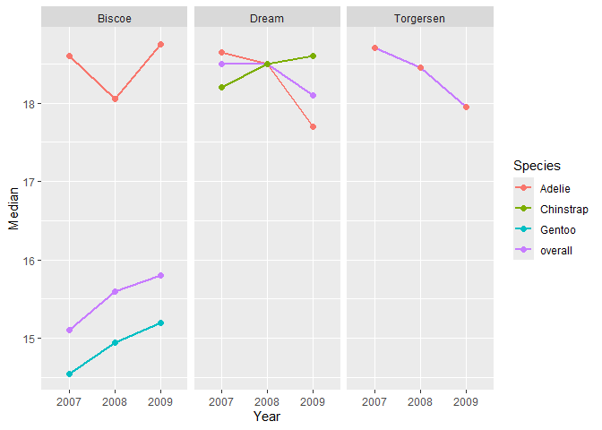

```r
penguinsSummary |>
  filter(variable_name == "bill_depth_mm") |>
  filterStrata(year != "overall", sex == "overall") |>
  scatterPlot(
    x = "year",
    y = "median",
    line = TRUE,
    point = TRUE,
    ribbon = FALSE,
    facet = "cdm_name",
    colour = "species"
  )
```

Additionally, we can use the function `themeVisOmop()` to change the default `ggplot2` style to our default style. Not only that, but we can use standard ggplot2 functionalities to the returned plot:

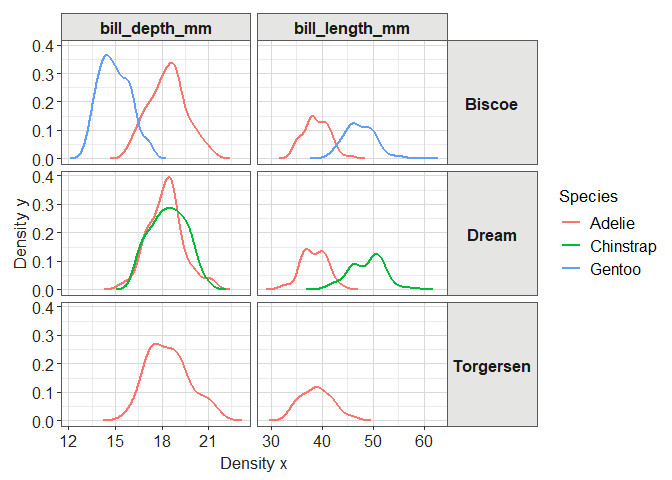

```r
penguinsSummary |>
  filter(variable_name %in% c("bill_length_mm", "bill_depth_mm"))|>
  filterStrata(year == "overall", sex == "overall") |>
  filterGroup(species != "overall") |>
  scatterPlot(
    x = "density_x",
    y = "density_y",
    line = TRUE,
    point = FALSE,
    ribbon = FALSE,
    facet = cdm_name ~ variable_name,
    colour = "species"
  ) +
  themeVisOmop() +
  ggplot2::facet_grid(cdm_name ~ variable_name, scales = "free_x")
```

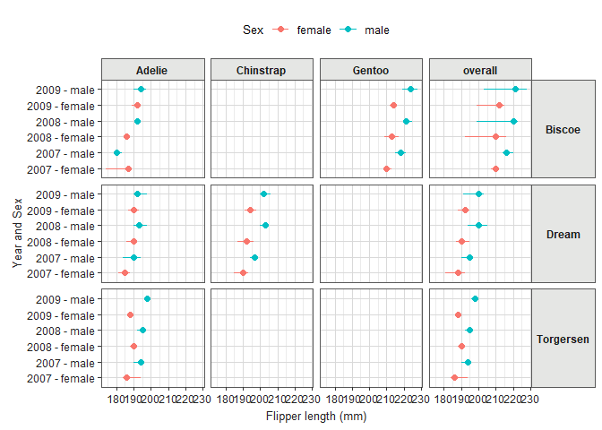

```r
penguinsSummary |>
  filter(variable_name == "flipper_length_mm") |>
  filterStrata(year != "overall", sex %in% c("female", "male")) |>
  scatterPlot(
    x = c("year", "sex"),
    y = "median",
    ymin = "q25",
    ymax = "q75",
    line = FALSE,
    point = TRUE,
    ribbon = FALSE,
    facet = cdm_name ~ species,
    colour = "sex",
    group = c("year", "sex")
  )  +
  themeVisOmop(fontsizeRef = 10, legendPosition = "top") +
  ggplot2::coord_flip() +
  ggplot2::labs(y = "Flipper length (mm)")
```

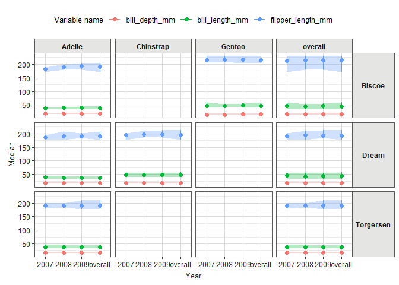

```r
penguinsSummary |>
  filter(variable_name %in% c(
    "flipper_length_mm", "bill_length_mm", "bill_depth_mm")) |>
  filterStrata(sex == "overall") |>
  scatterPlot(
    x = "year",
    y = "median",
    ymin = "min",
    ymax = "max",
    line = FALSE,
    point = TRUE,
    ribbon = TRUE,
    facet = cdm_name ~ species,
    colour = "variable_name",
    group = c("variable_name")
  ) +
  themeVisOmop(
    fontsizeRef = 10,
    legendPosition = "top"
  )
```

### Bar plot

Let’s create some simple bar plots:

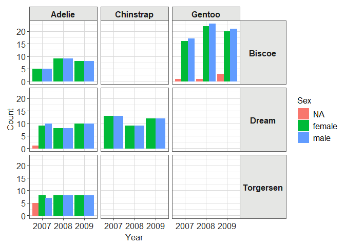

```r
penguinsSummary |>
  filter(variable_name == "number records") |>
  filterGroup(species != "overall") |>
  filterStrata(sex != "overall", year != "overall") |>
  barPlot(
    x = "year",
    y = "count",
    colour = "sex",
    facet = cdm_name ~ species
  ) +
  themeVisOmop()
```

### Box plot

Let’s create some box plots of their body mass:

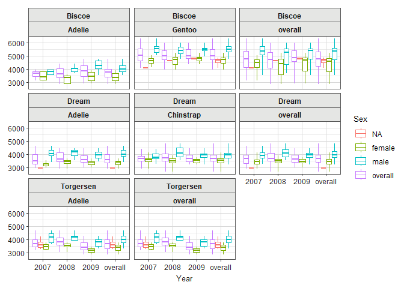

```r
penguinsSummary |>
  filter(variable_name == "body_mass_g") |>
  boxPlot(x = "year", facet = c("cdm_name", "species"), colour = "sex") +
  themeVisOmop(fontsizeRef = 10)
```

We can specify how we want to facet using a formula:

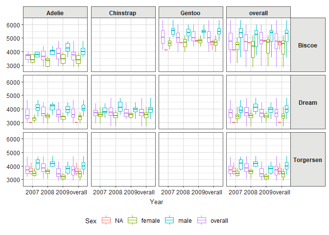

```r
penguinsSummary |>
  filter(variable_name == "body_mass_g") |>
  boxPlot(x = "year", facet = cdm_name ~ species, colour = "sex") +
  themeVisOmop(fontsizeRef = 10, legendPosition = "bottom")
```

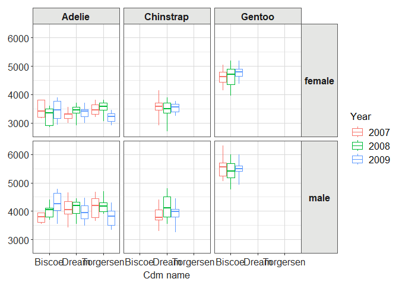

```r
penguinsSummary |>
  filter(variable_name == "body_mass_g") |>
  filterGroup(species != "overall") |>
  filterStrata(sex %in% c("female", "male"), year != "overall") |>
  boxPlot(x = "cdm_name", facet = sex ~ species, colour = "year") +
  themeVisOmop()
```

## Plotting with a `<data.frame>`

Plotting functions can also be used with a normal `<data.frame>`. In this case we will use the tidy format of `penguinsSummary`.

```r
penguinsTidy <- penguinsSummary |>
  filter(!estimate_name %in% c("density_x", "density_y")) |> # remove density for simplicity
  tidy()
penguinsTidy |> glimpse()
```

```
#> Rows: 720
#> Columns: 14
#> $ cdm_name       <chr> "Torgersen", "Torgersen", "Torgersen", "Torgersen", "To…
#> $ species        <chr> "overall", "overall", "overall", "overall", "overall", …
#> $ year           <chr> "overall", "overall", "overall", "overall", "overall", …
#> $ sex            <chr> "overall", "overall", "overall", "overall", "overall", …
#> $ variable_name  <chr> "number records", "bill_length_mm", "bill_depth_mm", "f…
#> $ variable_level <chr> NA, NA, NA, NA, NA, "female", "male", NA, NA, NA, NA, N…
#> $ count          <int> 52, NA, NA, NA, NA, 24, 23, 5, 20, 16, 16, NA, NA, NA, …
#> $ median         <int> NA, 38, 18, 191, 3700, NA, NA, NA, NA, NA, NA, 38, 38, …
#> $ q25            <int> NA, 36, 17, 187, 3338, NA, NA, NA, NA, NA, NA, 37, 35, …
#> $ q75            <int> NA, 41, 19, 195, 4000, NA, NA, NA, NA, NA, NA, 39, 41, …
#> $ min            <int> NA, 33, 15, 176, 2900, NA, NA, NA, NA, NA, NA, 34, 33, …
#> $ max            <int> NA, 46, 21, 210, 4700, NA, NA, NA, NA, NA, NA, 46, 45, …
#> $ count_missing  <int> NA, 1, 1, 1, 1, NA, NA, NA, NA, NA, NA, 1, 0, 0, 1, 0, …
#> $ percentage     <dbl> NA, NA, NA, NA, NA, 46.153846, 44.230769, 9.615385, NA,…
```

That as it can be seen is a normal data.frame:

```r
penguinsTidy |> class()
```

```
#> [1] "tbl_df"     "tbl"        "data.frame"
```

We can then do some custom plotting, for example replicating the last plot but from the tidy format:

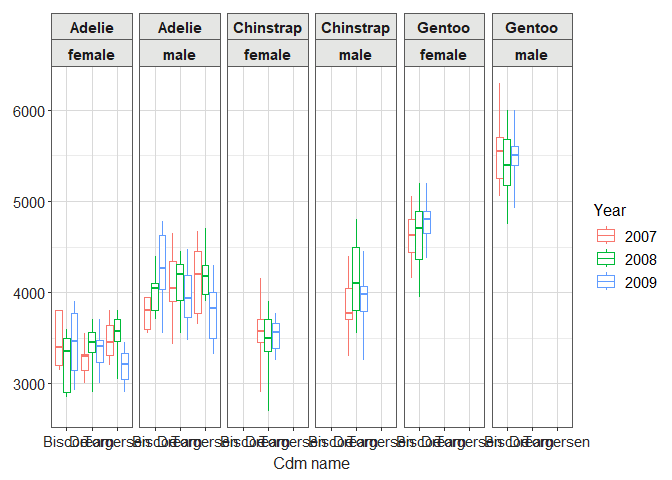

```r
penguinsTidy |>
  filter(
    variable_name == "body_mass_g",
    species != "overall",
    sex %in% c("female", "male"),
    year != "overall"
  ) |>
  boxPlot(x = "cdm_name", facet = ~ species + sex, colour = "year") +
  themeVisOmop(fontsizeRef = 12)
```

## Custom plotting

The tidy format is very useful to apply any other custom ggplot2 function that we may be interested on:

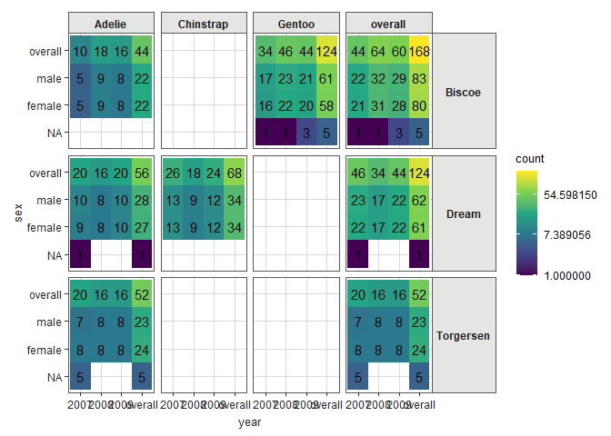

```r
library(ggplot2)
penguinsSummary |>
  filter(variable_name == "number records") |>
  tidy() |>
  ggplot(aes(x = year, y = sex, fill = count, label = count)) +
  themeVisOmop(fontsizeRef = 10) +
  geom_tile() +
  scale_fill_viridis_c(trans = "log") +
  geom_text() +
  facet_grid(cdm_name ~ species)
```

## Combine with `ggplot2`

The plotting functions are a wrapper around the ggplot2 package, outputs of the plotting functions can be later customised with ggplot2 and similar tools. For example we can use `ggplot2::labs()` to change the labels and `ggplot2::theme()` to move the location of the legend.

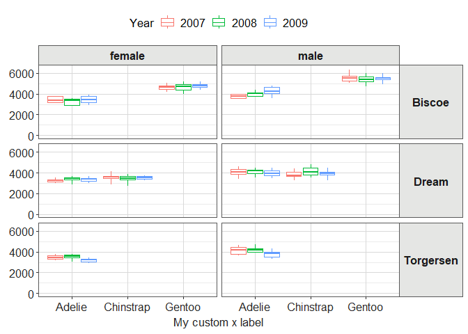

```r
penguinsSummary |>
  filter(
    group_level != "overall",
    strata_name == "year &&& sex",
    !grepl("NA", strata_level),
    variable_name == "body_mass_g") |>
  boxPlot(x = "species", facet = cdm_name ~ sex, colour = "year") +
  themeVisOmop(legendPosition = "top") +
  ylim(c(0, 6500)) +
  labs(x = "My custom x label")
```

You can also use `ggplot2::ggsave()` to later save one of this plots into ‘.png’ file.

```r
ggsave(
  "figure8.png", plot = last_plot(), device = "png", width = 15, height = 12,
  units = "cm", dpi = 300)
```

## Combine with `plotly`

Although the package currently does not provide any plotly functionality ggplots can be easily converted to `<plotly>` ones using the function `plotly::ggplotly()`. This can make the interactivity of some plots better.